# Lesson 7 - Parkinson PCR

## Author - AlexSkrn

### Description:

Perform Principal Component Regression on a [dataset that tracked patients with Parkinson's Disease](https://archive.ics.uci.edu/ml/datasets/parkinsons+telemonitoring).

Citation: A Tsanas, MA Little, PE McSharry, LO Ramig (2009) 'Accurate telemonitoring of Parkinson's disease progression by non-invasive speech tests', IEEE Transactions on Biomedical Engineering.

About the data: This dataset is composed of a range of biomedical voice measurements from 42 people with early-stage Parkinson's disease recruited to a six-month trial of a telemonitoring device for remote symptom progression monitoring. The recordings were automatically captured in the patient's homes.

#### Instructions:

1. Load the dataset.
2. Create the X-matrix (one-hot encoding categorical factors).
3. Scale the X-matrix.
4. Create the principal components and do a simple plot of the explained variance.
5. PCR - Linear regression with the principal components.

Report on:

1. Number of components before and after (choose a smaller number of principal components and explain how you chose them).
2. Interpret the adjusted R-squared.

```python
url = 'https://archive.ics.uci.edu/ml/machine-learning-databases/parkinsons/telemonitoring/parkinsons_updrs.data'
filename = 'parkinsons_updrs.data'
```

```python
import pandas as pd
import numpy as np
from sklearn.decomposition import PCA
import matplotlib.pyplot as plt
import statsmodels.formula.api as sm
import seaborn as sns
```

```python
# parkinsons_df = pd.read_csv(filename)
# parkinsons_df.head()

# Load data
def load_data(a_url, path):
    """Load data from a url or local path."""
    print("Loading the data set from a local file if it exists...")
    try:
        data_set = pd.read_csv(path)
        print("Data set loaded from a local file.")
    except FileNotFoundError:
        print("File not found, loading from Internet...")
        data_set = pd.read_csv(a_url)
        print("Data set loaded from the Internet.")

    return data_set

parkinsons_df = load_data(url, filename)
parkinsons_df.head()
```

```
Loading the data set from a local file if it exists...
File not found, loading from Internet...
Data set loaded from the Internet.
```

|  | subject# | age | sex | test_time | motor_UPDRS | total_UPDRS | Jitter(%) | Jitter(Abs) | Jitter:RAP | Jitter:PPQ5 | ... | Shimmer(dB) | Shimmer:APQ3 | Shimmer:APQ5 | Shimmer:APQ11 | Shimmer:DDA | NHR | HNR | RPDE | DFA | PPE |
| --- | --- | --- | --- | --- | --- | --- | --- | --- | --- | --- | --- | --- | --- | --- | --- | --- | --- | --- | --- | --- | --- |
| 0 | 1 | 72 | 0 | 5.6431 | 28.199 | 34.398 | 0.00662 | 0.000034 | 0.00401 | 0.00317 | ... | 0.230 | 0.01438 | 0.01309 | 0.01662 | 0.04314 | 0.014290 | 21.640 | 0.41888 | 0.54842 | 0.16006 |
| 1 | 1 | 72 | 0 | 12.6660 | 28.447 | 34.894 | 0.00300 | 0.000017 | 0.00132 | 0.00150 | ... | 0.179 | 0.00994 | 0.01072 | 0.01689 | 0.02982 | 0.011112 | 27.183 | 0.43493 | 0.56477 | 0.10810 |
| 2 | 1 | 72 | 0 | 19.6810 | 28.695 | 35.389 | 0.00481 | 0.000025 | 0.00205 | 0.00208 | ... | 0.181 | 0.00734 | 0.00844 | 0.01458 | 0.02202 | 0.020220 | 23.047 | 0.46222 | 0.54405 | 0.21014 |
| 3 | 1 | 72 | 0 | 25.6470 | 28.905 | 35.810 | 0.00528 | 0.000027 | 0.00191 | 0.00264 | ... | 0.327 | 0.01106 | 0.01265 | 0.01963 | 0.03317 | 0.027837 | 24.445 | 0.48730 | 0.57794 | 0.33277 |
| 4 | 1 | 72 | 0 | 33.6420 | 29.187 | 36.375 | 0.00335 | 0.000020 | 0.00093 | 0.00130 | ... | 0.176 | 0.00679 | 0.00929 | 0.01819 | 0.02036 | 0.011625 | 26.126 | 0.47188 | 0.56122 | 0.19361 |

5 rows × 22 columns

```python
parkinsons_df.columns
```

```
Index(['subject#', 'age', 'sex', 'test_time', 'motor_UPDRS', 'total_UPDRS',
       'Jitter(%)', 'Jitter(Abs)', 'Jitter:RAP', 'Jitter:PPQ5', 'Jitter:DDP',
       'Shimmer', 'Shimmer(dB)', 'Shimmer:APQ3', 'Shimmer:APQ5',
       'Shimmer:APQ11', 'Shimmer:DDA', 'NHR', 'HNR', 'RPDE', 'DFA', 'PPE'],
      dtype='object')
```

```python
# Define the target and features:
target_label = 'total_UPDRS'
non_features = ['subject#', 'age', 'sex', 'test_time', 'motor_UPDRS']
feature_labels = [x for x in parkinsons_df.columns if x not in [target_label] + non_features]

# Filter out non-features and non-targets
parkinsons_df = parkinsons_df.drop(non_features, axis=1)

# One-hot encode inputs
parkinsons_expanded = pd.get_dummies(parkinsons_df, drop_first=True)
print('DataFrame one-hot-expanded shape: {}'.format(parkinsons_expanded.shape))

# Get target and original x-matrix
y = parkinsons_df[target_label]
X = parkinsons_df.as_matrix(columns=feature_labels)
```

```
DataFrame one-hot-expanded shape: (5875, 17)
```

```python
# Scale function
def scale(col):
    mean_col = np.mean(col)
    sd_col = np.std(col)
    std = (col - mean_col) / sd_col
    return std
```

```python
# Scale all columns first

# Create x-scaled (look into the function np.apply_along_axis to apply 'scale' function
#    to each column).
x_scaled = np.apply_along_axis(scale, 0, X)
# Create a scaled y-target.
y_scaled = np.apply_along_axis(scale, 0, y)
```

```python
# PCR!!
pca = PCA(n_components = x_scaled.shape[1])
pca_result = pca.fit_transform(x_scaled)

column_names = ['pc' + str(ix+1) for ix in range(x_scaled.shape[1])]
pca_df = pd.DataFrame(data = pca_result, columns=column_names)
pca_df[target_label] = y_scaled
```

```python
pca.explained_variance_
```

```
array([1.12629682e+01, 1.67318476e+00, 1.24072101e+00, 7.64997339e-01,
       3.09303033e-01, 2.22920126e-01, 1.72792228e-01, 1.61771857e-01,
       1.03092483e-01, 4.35311730e-02, 2.02908815e-02, 1.40172168e-02,
       8.66818249e-03, 4.46498205e-03, 3.77897603e-07, 2.08498997e-08])
```

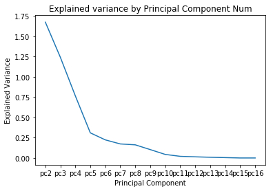

```python
# Plot the explained variance for all principal components.
# Note: If the first value is too large, it may dwarf how the rest look.
# You may consider plotting starting with the 2nd value (python index at 1).
plt.plot(column_names[1:], pca.explained_variance_[1:])
plt.title('Explained variance by Principal Component Num')
plt.xlabel('Principal Component')
plt.ylabel('Explained Variance')
```

```
                            OLS Regression Results
==============================================================================
Dep. Variable:            total_UPDRS   R-squared:                       0.099
Model:                            OLS   Adj. R-squared:                  0.098
Method:                 Least Squares   F-statistic:                     80.83
Date:                Sat, 23 Feb 2019   Prob (F-statistic):          2.63e-127
Time:                        11:20:38   Log-Likelihood:                -8029.1
No. Observations:                5875   AIC:                         1.608e+04
Df Residuals:                    5866   BIC:                         1.614e+04
Df Model:                           8
Covariance Type:            nonrobust
==============================================================================
                 coef    std err          t      P>|t|      [0.025      0.975]
------------------------------------------------------------------------------
Intercept   3.543e-16      0.012   2.86e-14      1.000      -0.024       0.024
pc1            0.0309      0.004      8.379      0.000       0.024       0.038
pc2            0.0328      0.010      3.426      0.001       0.014       0.052
pc3           -0.0230      0.011     -2.066      0.039      -0.045      -0.001
pc4           -0.2295      0.014    -16.196      0.000      -0.257      -0.202
pc5           -0.2666      0.022    -11.967      0.000      -0.310      -0.223
pc7            0.0837      0.030      2.809      0.005       0.025       0.142
pc8            0.3429      0.031     11.129      0.000       0.282       0.403
pc9            0.1857      0.039      4.811      0.000       0.110       0.261
==============================================================================
Omnibus:                      170.573   Durbin-Watson:                   0.136
Prob(Omnibus):                  0.000   Jarque-Bera (JB):              180.751
Skew:                           0.417   Prob(JB):                     5.63e-40
Kurtosis:                       2.791   Cond. No.                         10.5
==============================================================================

Warnings:
[1] Standard Errors assume that the covariance matrix of the errors is correctly specified.
```

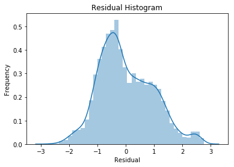

```python
# Perform linear regression with the first N columns.
# n = 9
# formula_start = target_label + ' ~ '
# formula_terms = ['pc' + str(x+1) for x in range(n)]
# formula_end = ' + '.join(formula_terms)
# formula_final = formula_start + formula_end

formula_final = target_label + ' ~ pc1 + pc2 + pc3 + pc4 + pc5 + pc7 + pc8 + pc9'
# formula_final = target_label + ' ~ pc1 + pc2 + pc7 + pc8 + pc9'

pcr_model = sm.ols(formula = formula_final, data = pca_df)

results = pcr_model.fit()

# Get most of the linear regression statistics we are interested in:
print(results.summary())

# Plot a histogram of the residuals
sns.distplot(results.resid, hist = True)
plt.xlabel('Residual')
plt.ylabel('Frequency')
plt.title('Residual Histogram')
```

Summary of your results!

1. Number of components before and after (choose a smaller number of principal components and explain how you chose them).
2. Interpret the adjusted R-squared.